# Data science per psicologi - demo 23.01

Corrado Caudek

2022-04-21

```r
suppressPackageStartupMessages({
  library("here")
  library("tidyverse")
  library("bayesplot")
  library("rstan")
  library("cmdstanr")
  library("posterior")
})

rstan_options(auto_write = TRUE) # avoid recompilation of models
options(mc.cores = parallel::detectCores()) # parallelize across all CPUs
Sys.setenv(LOCAL_CPPFLAGS = "-march=native") # improve execution time

theme_set(bayesplot::theme_default(base_size = 12))
bayesplot::color_scheme_set("gray")
set.seed(84735)

knitr::opts_chunk$set(
  collapse = TRUE,
  tidy = 'styler',
  fig.width = 6,
  fig.asp = 0.618 # 1 / phi
)
```

# Modello di regressione in Stan

In questo demo ci poniamo il problema di implementare il modello di regressione semplice usando Stan.

Useremo i dati contenuti nel pacchetto `sur`.

```r
library("sur")
data(Brainsz)
glimpse(Brainsz)
```

```
## Rows: 40
## Columns: 7
## $ ID     <dbl> 2, 3, 4, 9, 10, 12, 13, 18, 20, 21, 22, 24, 26, 28, 32, 33, 34,…
## $ GENDER <fct> Male, Male, Male, Male, Male, Male, Male, Male, Male, Male, Mal…
## $ FSIQ   <dbl> 140, 139, 133, 89, 133, 141, 135, 100, 80, 83, 97, 139, 141, 10…
## $ VIQ    <dbl> 150, 123, 129, 93, 114, 150, 129, 96, 77, 83, 107, 145, 145, 96…
## $ PIQ    <dbl> 124, 150, 128, 84, 147, 128, 124, 102, 86, 86, 84, 128, 131, 11…
## $ MRI    <dbl> 1001121, 1038437, 965353, 904858, 955466, 1079549, 924059, 9450…
## $ IQDI   <fct> Higher IQ, Higher IQ, Higher IQ, Lower IQ, Higher IQ, Higher IQ…
```

Riporto qui sotto la descrizione del set di dati.

> The data are based on a study by Willerman et al. (1991) of the relationships between brain size, gender, and intelligence. The research participants consisted of 40 right-handed introductory psychology students with no history of alcoholism, unconsciousness, brain damage, epilepsy, or heart disease who were selected from a larger pool of introductory psychology students with total Scholastic Aptitude Test Scores higher than 1350 or lower than 940. The students in the study took four subtests (Vocabulary, Similarities, Block Design, and Picture Completion) of the Wechsler (1981) Adult Intelligence Scale-Revised. Among the students with Wechsler full-scale IQ’s less than 103, 10 males and 10 females were randomly selected. Similarly, among the students with Wechsler full-scale IQ’s greater than 130, 10 males and 10 females were randomly selected, yielding a randomized blocks design. MRI scans were performed at the same facility for all 40 research participants to measure brain size. The scans consisted of 18 horizontal MRI images. The computer counted all pixels with non-zero gray scale in each of the 18 images, and the total count served as an index for brain size. The dataset and description are adapted from the Data and Story Library (DASL) website.

Mi concentrerò sulla relazione tra FSIQ e grandezza del cervello.

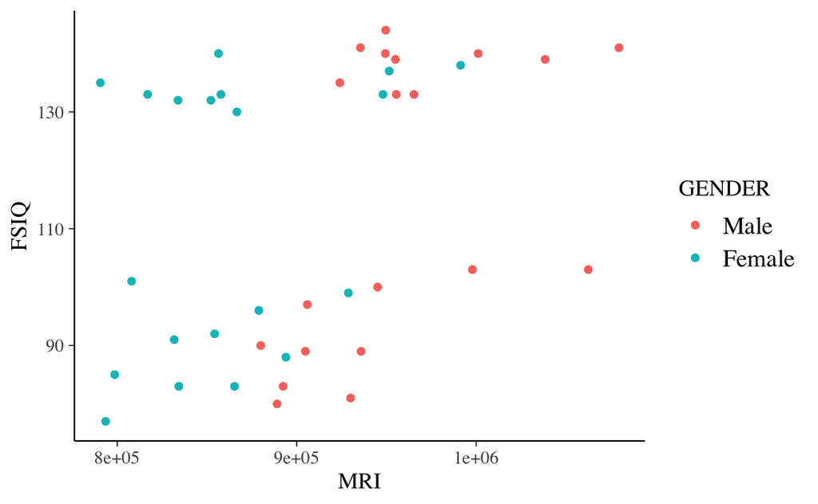

```r
Brainsz %>%
  ggplot(aes(x = MRI, y = FSIQ, color = GENDER)) +
  geom_point()
```

I dati rappresentati nel diagramma a dispersione suggeriscono che, in questo piccolo campione, sembra esserci un’associazione positiva tra MRI e FSIQ per i maschi, ma non per le femmine.

Per fare un esercizio, ci concentriamo sui maschi.

```r
males <- Brainsz %>%
  dplyr::filter(GENDER == "Male")
```

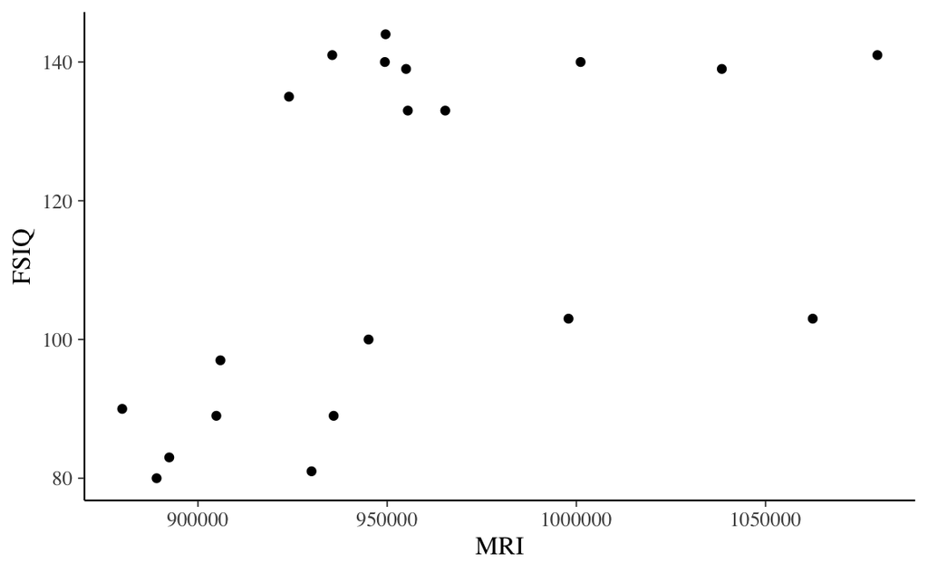

```r
males %>%
  ggplot(aes(x = MRI, y = FSIQ)) +
  geom_point()
```

Per semplificare l’analisi, standardizzo i dati.

```r
males$fsiq <- scale(males$FSIQ) %>%
  as.numeric()

males$mri <- scale(males$MRI) %>%
  as.numeric()
```

Esamino il diagramma a dispersione per le due variabili standardizzate.

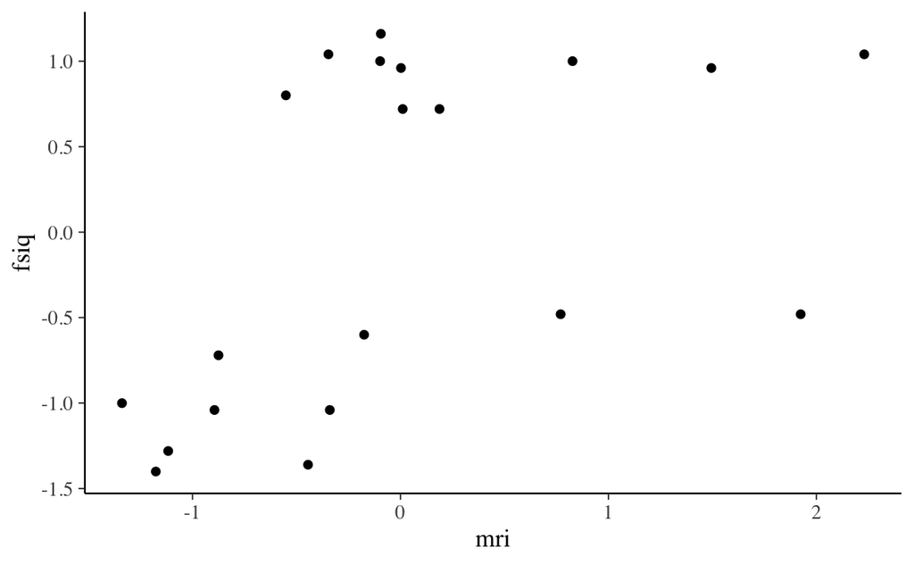

```r
males %>%
  ggplot(aes(x = mri, y = fsiq)) +
  geom_point()
```

### I dati in Stan

Inserisco i dati in una lista così come richiesto da Stan:

```r
data_list <- list(
  N = length(males$fsiq),
  x = males$mri,
  y = males$fsiq
)

data_list
```

```
## $N
## [1] 20
##
## $x
##  [1]  0.827481291  1.494894918  0.187754349 -0.894226231  0.010920859
##  [6]  2.230201730 -0.550807616 -0.174694390 -1.176369278 -1.116685516
## [11] -0.874874169  0.002639893 -0.346287442  1.924592966 -0.094191958
## [16]  0.770319378 -1.339055374 -0.097661737 -0.444263963 -0.339687709
##
## $y
##  [1]  1.0005478  0.9605259  0.7203944 -1.0405697  0.7203944  1.0405697
##  [7]  0.8004383 -0.6003287 -1.4007669 -1.2807012 -0.7203944  0.9605259
## [13]  1.0405697 -0.4802630  1.1606355 -0.4802630 -1.0005478  1.0005478
## [19] -1.3607450 -1.0405697
```

Definizione il modello in linguaggio Stan.

```r
model_string <- "
  data {
    int<lower=0> N;     // number of data points
    vector[N] x;        // covariate / predictor
    vector[N] y;        // target
  }
  parameters {
    real alpha;          // intercept
    real beta;           // slope
    real<lower=0> sigma; // standard deviation is constrained to be positive
  }
  transformed parameters {
    // deterministic transformation of parameters and data
    vector[N] mu = alpha + beta * x; // linear model
  }
  model {
    alpha ~ normal(0, 2.5); // prior
    beta ~ normal(0, 2.5);  // prior
    sigma ~ normal(0, 10);  // as sigma is constrained to be positive,
                            // this is same as half-normal prior
    y ~ normal(mu, sigma);  // likelihood
  }
  generated quantities {
  vector[N] y_rep;
    // the generated quantities block requires a for loop
    for (i in 1:N) {
      y_rep[i] = normal_rng(alpha + beta * x[i], sigma);
    }
  }
"
```

Salvo il modello Stan in un file.

```r
writeLines(model_string, con = "code/lmod_1.stan")
file <- file.path("code", "lmod_1.stan")
```

Compilo il modello.

```r
mod <- cmdstan_model(file)
```

Eseguo il campionamento MCMC.

```r
fit <- mod$sample(
  data = data_list,
  iter_sampling = 4000L,
  iter_warmup = 2000L,
  seed = 84735,
  chains = 4L,
  refresh = 0,
  thin = 1
)
```

## Diagnostiche

Le seguenti diagnostiche sono spiegate nel *CmdStan User’s Guide*.

```r
fit$cmdstan_diagnose()
## Processing csv files: /var/folders/hl/dt523djx7_q7xjrthzjpdvc40000gn/T/RtmpW58CDO/lmod_1-202204211135-1-5f43f5.csv, /var/folders/hl/dt523djx7_q7xjrthzjpdvc40000gn/T/RtmpW58CDO/lmod_1-202204211135-2-5f43f5.csv, /var/folders/hl/dt523djx7_q7xjrthzjpdvc40000gn/T/RtmpW58CDO/lmod_1-202204211135-3-5f43f5.csv, /var/folders/hl/dt523djx7_q7xjrthzjpdvc40000gn/T/RtmpW58CDO/lmod_1-202204211135-4-5f43f5.csv
##
## Checking sampler transitions treedepth.
## Treedepth satisfactory for all transitions.
##
## Checking sampler transitions for divergences.
## No divergent transitions found.
##
## Checking E-BFMI - sampler transitions HMC potential energy.
## E-BFMI satisfactory.
##
## Effective sample size satisfactory.
##
## Split R-hat values satisfactory all parameters.
##
## Processing complete, no problems detected.
```

## Posterior predictive checks

Esaminiamo i posterior predictive checks.

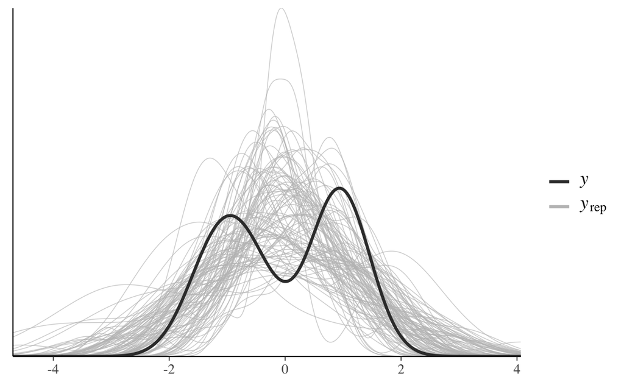

```r
y_rep <- fit$draws("y_rep", format = "matrix")
ppc_dens_overlay(y = data_list$y, yrep = y_rep[1:100, ])
```

I dati di partenza hanno una forma bimodale, per cui il fit del modello non è perfetto.

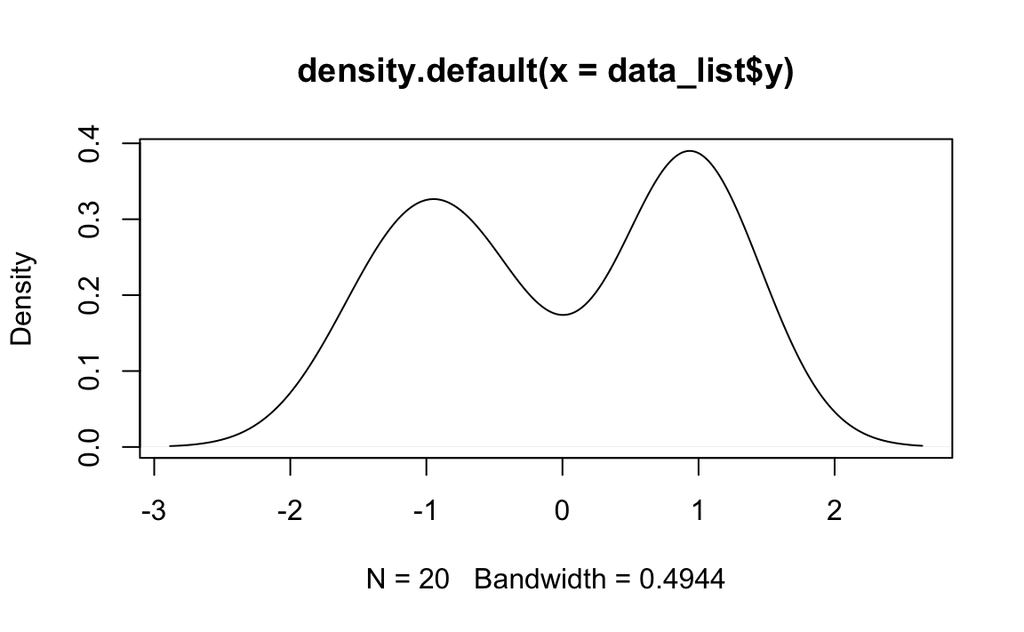

```r
plot(density(data_list$y))
```

Le curve in grigio sono generate usando i valori predetti

$$\hat{y} = a + b x,$$
laddove $a$ e $b$ sono valori presi a caso dalla distribuzione a posteriori dei parametri. Considerando il campione di partenza, si può dire che il fit sia ragionevole.

Possiamo anche esaminare la distribuzione predittiva a posteriori di varie statistiche campionarie.

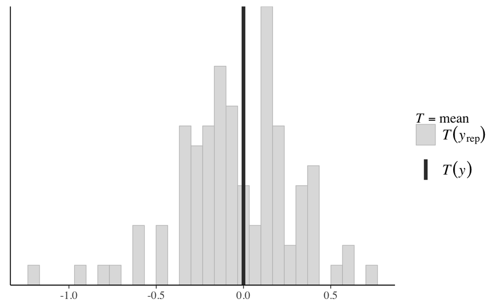

```r
ppc_stat(y = data_list$y, yrep = y_rep[1:100, ], stat = "mean")
## `stat_bin()` using `bins = 30`. Pick better value with `binwidth`.
```

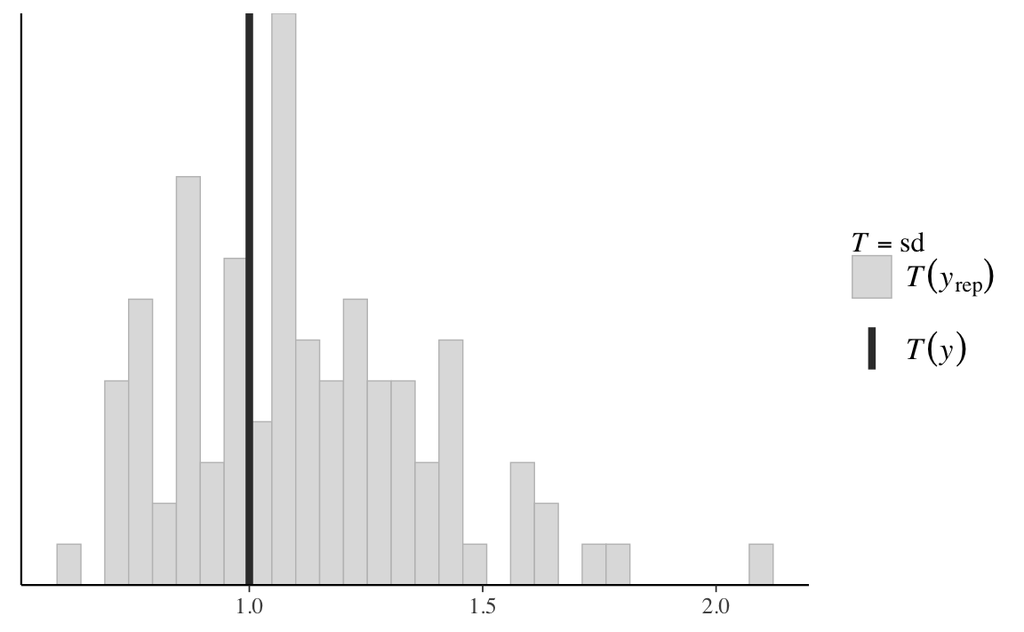

```r
ppc_stat(y = data_list$y, yrep = y_rep[1:100, ], stat = "sd")
## `stat_bin()` using `bins = 30`. Pick better value with `binwidth`.
```

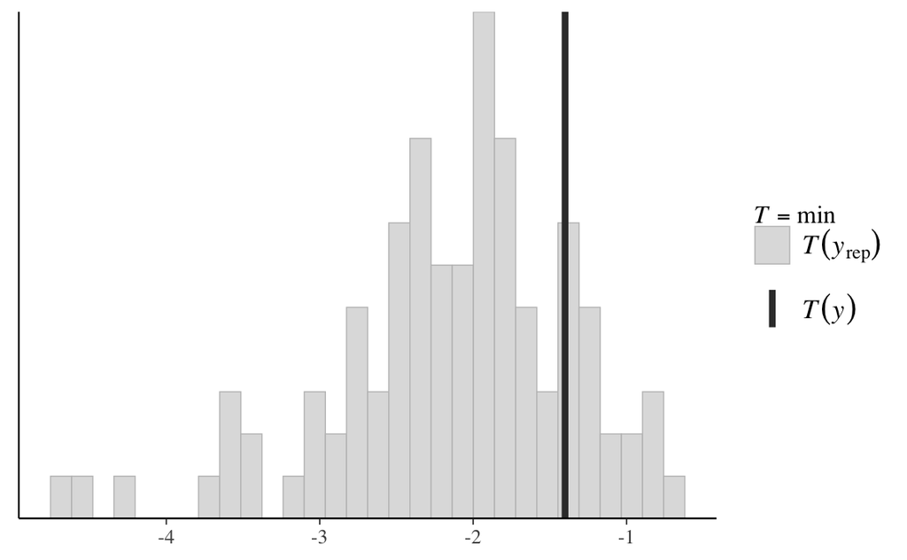

```r
ppc_stat(y = data_list$y, yrep = y_rep[1:100, ], stat = "min")
## `stat_bin()` using `bins = 30`. Pick better value with `binwidth`.
```

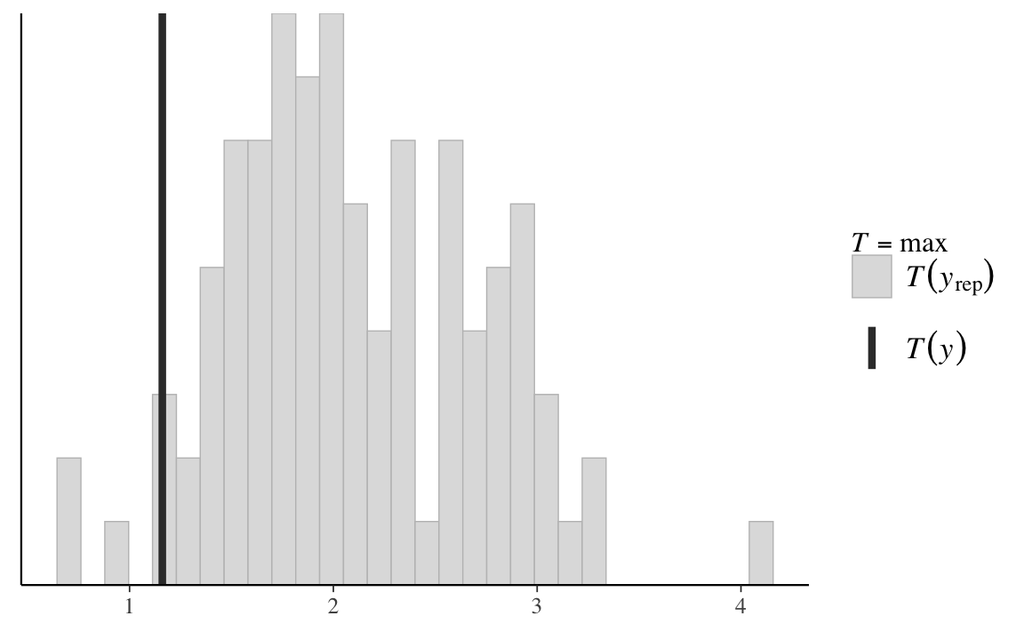

```r
ppc_stat(y = data_list$y, yrep = y_rep[1:100, ], stat = "max")
## `stat_bin()` using `bins = 30`. Pick better value with `binwidth`.
```

## Stime a posteriori

Esamino i risultati del campionamento MCMC.

```r
post <- fit$draws()
```

Estraggo solo le stime a posteriori dei parametri di interesse.

```r
post_parms <- subset_draws(post, c("alpha", "beta", "sigma"))
posterior::summarise_draws(post_parms)
```

```
## # A tibble: 3 × 10
##   variable    mean  median    sd   mad     q5   q95  rhat ess_bulk ess_tail
##   <chr>      <dbl>   <dbl> <dbl> <dbl>  <dbl> <dbl> <dbl>    <dbl>    <dbl>
## 1 alpha    0.00383 0.00420 0.221 0.216 -0.360 0.362  1.00   12466.    9495.
## 2 beta     0.492   0.494   0.225 0.216  0.125 0.859  1.00   12377.   10232.
## 3 sigma    0.960   0.936   0.175 0.162  0.720 1.29   1.00   10206.    9285.
```

Trovo l’intervallo di credibilità al 95%.

```r
posterior::summarise_draws(
  post_parms,
  ~ quantile(.x, probs = c(0.025, 0.975))
)
```

```
## # A tibble: 3 × 3
##   variable  `2.5%` `97.5%`
##   <chr>      <dbl>   <dbl>
## 1 alpha    -0.438    0.439
## 2 beta      0.0476   0.931
## 3 sigma     0.690    1.37
```

Calcolo la probabilità di $\beta > 0$.

```r
draws_lin <- as_draws_df(fit$draws())
mean(draws_lin[, "beta"] > 0)
```

[output not shown]

I risultati ottenuti sono molto simili a quelli trovati con l’approccio frequentista.

```r
fm <- lm(fsiq ~ mri, males)
summary(fm)
```

```
##
## Call:
## lm(formula = fsiq ~ mri, data = males)
##
## Residuals:
##     Min      1Q  Median      3Q     Max
## -1.4394 -0.7468 -0.1776  0.7760  1.2131
##
## Coefficients:
##              Estimate Std. Error t value Pr(>|t|)
## (Intercept) 1.607e-16  1.992e-01   0.000   1.0000
## mri         4.984e-01  2.043e-01   2.439   0.0253 *
## ---
## Signif. codes:  0 '***' 0.001 '**' 0.01 '*' 0.05 '.' 0.1 ' ' 1
##
## Residual standard error: 0.8907 on 18 degrees of freedom
## Multiple R-squared:  0.2484, Adjusted R-squared:  0.2066
## F-statistic: 5.948 on 1 and 18 DF,  p-value: 0.02532
```

Esamino il “mixing” delle catene.

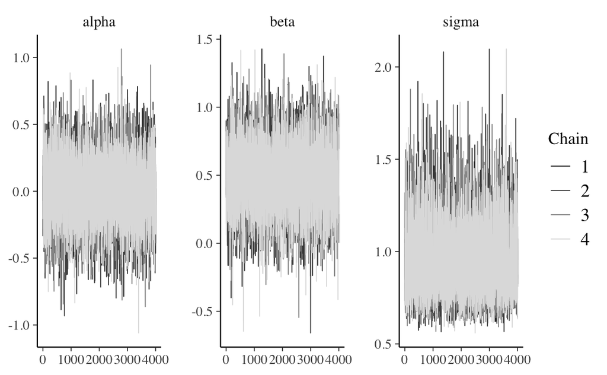

```r
bayesplot::mcmc_trace(post, pars = c("alpha", "beta", "sigma"))
```

Creo un grafico della distribuzione a posteriori dei tre parametri.

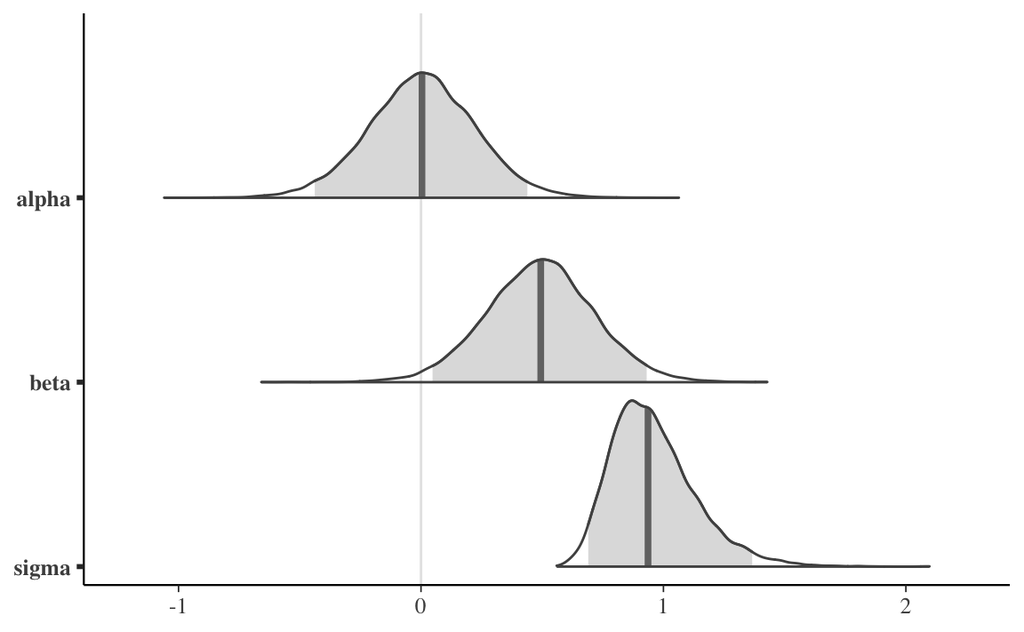

```r
bayesplot::mcmc_areas(post, pars = c("alpha", "beta", "sigma"), prob = 0.95)
```

Una rappresentazione della retta di regressione con l’intervallo di credibilità al 90% è la seguente.

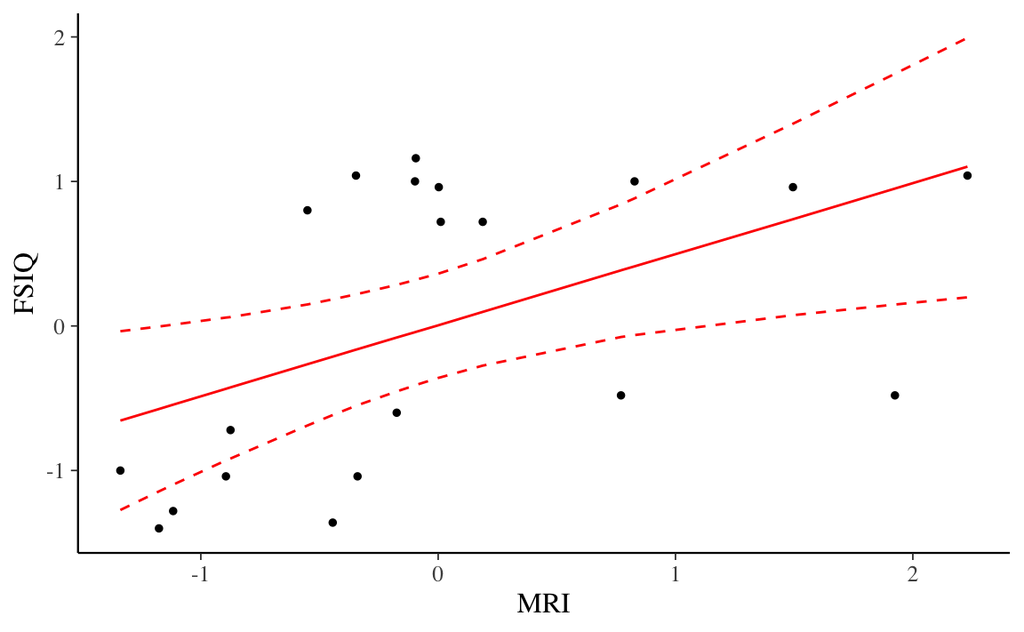

```r
mu <- draws_lin %>%
  as_draws_df() %>%
  as_tibble() %>%
  select(starts_with("mu")) %>%
  apply(2, quantile, c(0.05, 0.5, 0.95)) %>%
  t() %>%
  data.frame(x = data_list$x, .) %>%
  gather(pct, y, -x)

ggplot() +
  geom_point(aes(x, y), data = data.frame(data_list), size = 1) +
  geom_line(aes(x, y, linetype = pct), data = mu, color = "red") +
  scale_linetype_manual(values = c(2, 1, 2)) +
  labs(y = "FSIQ", x = "MRI") +
  guides(linetype = "none")
```

## Conclusioni

Dato che abbiamo standardizzato i dati, il parametro $\alpha$ deve essere 0.